# MATH1115 PROJECT 1 National Centre for Health Statistics (NCHS)

Paul Sevastos, Patrick Conroy, Jonathan Then

23/08/2019

# Center for Disease Control and Intervention

**Executive Summary**

The survey data was collected by the US National Center for Health Statistics (NCHS). Each year, approximately 5,000 individuals are interviewed in their homes. The data covers 1999-2004 and highlights many key “lifestyle” statistics of a large population size. The survey covered areas such as diabetes, smoking, BMI, cholesterol levels and height. Hence, allowing us to see trends between some of these factors and the difference between sexes. Of note; older populations were more likely to smoke amongst males and females.

URL: https://www.cdc.gov/nchs/index.htm

The raw survey collected by the U.S. government included a large sample size of over 31,000 individuals. Therefore, the dataset is reliable with some validity issues due to lifestyle surveys being susceptible to exaggeration or underreporting.

```r
nchsoriginal <- read.csv("nchs.csv")

dim(nchsoriginal)
#To see how big our dataset is, 31126 obs & 31 var.

str(nchsoriginal)
#To view the structure of our dataset.

head(nchsoriginal)
#To view the first few columns of large data sets.

colnames(nchsoriginal)
#To determine names of all the variables.
```

**By looking at the relationship between the smoker status (i.e. Smoker or Non-Smoker) and the age of participants, we wanted to find out if habits change as we age? Once addicted, is it possible to cease?**

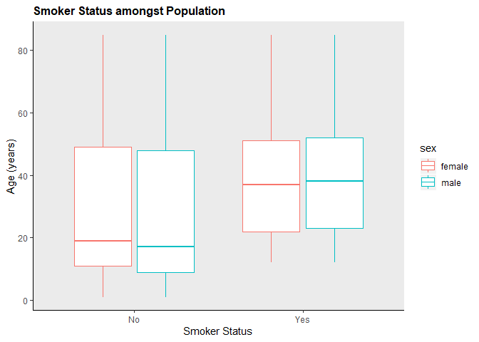

Observation 1: Younger males are less likely to smoke than their female counterparts.

Observation 2: The smokers are usually the older generation. This could be due to the younger people being more educated on the harmful effects of smoking and law restrictions.

**Is there a relationship between HDL Cholesterol and BMI? Is there a difference between gender?**

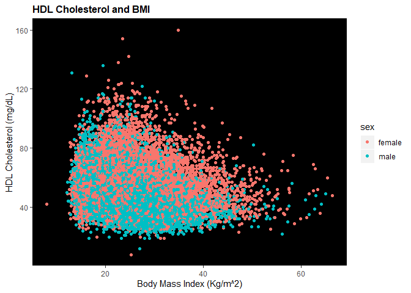

Observation 1: HDL is the “good” cholesterol and as a result is more prevalent in healthier individuals. The healthy BMI range is between 19-30.

Observation 2: The female population may have what appears to be higher BMI and HDL cholesterol range. This suggesting that they may be more protected against heart disease than males at the same BMI.

**Is ethnicity a factor of getting diabetes?**

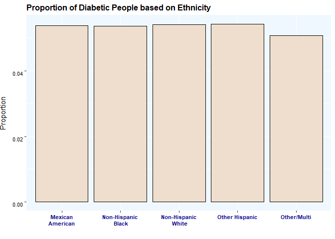

Observation: The proportion of people who have diabetes is constant throughout the different ethnicities. This suggests that among the listed ethnicities, one isn’t more susceptible to diabetes than others.

**Wealth is said to be a effective predictor of Body Mass Index (BMI). Is there a correlation between BMI and income?**

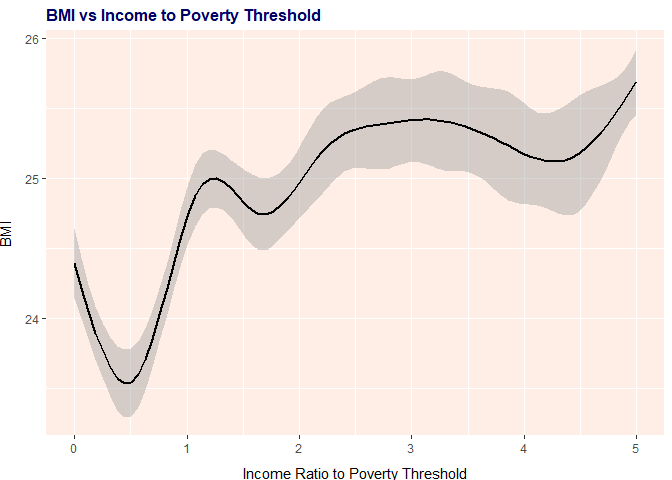